# glom() Demo - checking for cambic horizon criteria

Andrew Brown

Last updated: 2019/02/14

In this demo, we use the *aqp* functions `glom()` and `profileApply()` to analyze a depth-subset of horizons from each profile in a *SoilProfileCollection*.

`glom()` returns the horizon(s) that intersect the specified depth [*z1*] or depth interval [*z1*, *z2*].

### Sandy Cambic Checker

This demonstration script loads some components from Yosemite National Park (*CA790*).

First, the script queries records populated in the *Component Diagnostic Features* (`codiagfeatures`) table for a set of `cokey`s. Then we add the cambic top and bottom depth as *site-level* variables for each component that has a cambic.

A custom function `has_sandy_cambic()` is defined to use `glom()` on each profile (`p`) in `my.spc`.

`glom()` is used along with the top and bottom depth of the cambic (which we added to `site` table) to get *all horizons that are part of the specified (cambic) depth range*.

A pair of regular expression patterns are used to check the `glom()`-ed horizons for stratified and/or sandy textures. If either stratified or sandy textures are found, the function returns `TRUE`. Otherwise, the function returns `FALSE`.

In this simple example, two out of four components have sandy cambics.

The *Glacierpoint* series (*Sandy-skeletal, isotic Xeric Dystrocryepts*) is defined as having **either** an Umbric epipedon **OR** a cambic horizon. It appears that cambic horizons were populated even for the components whose RV textures do not meet cambic criteria.

```r
# load soilDB
library(soilDB)

# get components from Yosemite National Park for a sandy-skeletal, cryic, inceptisol
my.spc <- fetchSDA_component(WHERE="compname = 'Glacierpoint'")
```

`fetchSDA_component()` does not return diagnostic feature info by default. We need to query SDA specifically to obtain that info.

```r
# custom function using SDA_query() to get the diagnostic table
get_SDA_diagnostics <- function(my.spc) {
  target_cokeys <- site(my.spc)[,idname(my.spc)]
  q <- paste0('SELECT * FROM codiagfeatures WHERE cokey IN ', format_SQL_in_statement(target_cokeys), ";")
  return(SDA_query(q))
}

# query diagnostic info from SDA
diag.info <- get_SDA_diagnostics(my.spc)

# rename the RV depths for plotting
diag.info$featdept <- diag.info$featdept_r
diag.info$featdepb <- diag.info$featdepb_r

# set diagnostics slot of my.spc to contain SDA diagnostics
diagnostic_hz(my.spc) <- diag.info
```

SPC-creating functions may require you to independently query the diagnostic features into a *data.frame* and set them for your SPC, as we did above. Alternately, you can create your SPC other ways. The `fetchNASIS_XXX()` results include the diagnostic feature table *by default*.

```r
## You don't need to use SDA! You can get components from your NASIS selected set.
## To use component records from NASIS, use the code below to make `my.spc.nasis`
my.spc.nasis <- fetchNASIS_components()
```

Access the SPC `@diagnostics` slot (which we just filled in), figure out which pedons have cambics, and then add their cambic top and bottom depth to the `site` table.

```r
# copy contents of diagnostics slot
diagz <- diagnostic_hz(my.spc)

# take just records that are featkind == cambic
diag.sub <- diagz[grepl(diagz$featkind, pattern="[Cc]ambic"),]

# get just the unique ID and RV top and bottom depths for join to site table
diag.sub <- diag.sub[,c(idname(my.spc),'featdept_r','featdepb_r')]

# rename top and bottom depth to be more connotative
names(diag.sub) <- c(idname(my.spc),'cambicdept_r','cambicdepb_r')
```

Make a subset SPC that is just the profiles that have cambic horizons in their diagnostics table.

```r
my.spc.sub <- my.spc[site(my.spc)[,idname(my.spc)] %in% diag.sub[,idname(my.spc)], ]

# add our modified diagnostic depth table to site table of SPC
site(my.spc.sub) <- diag.sub
```

Visually show sand contents by horizon, with cambic top and bottom depths as bracket annotation.

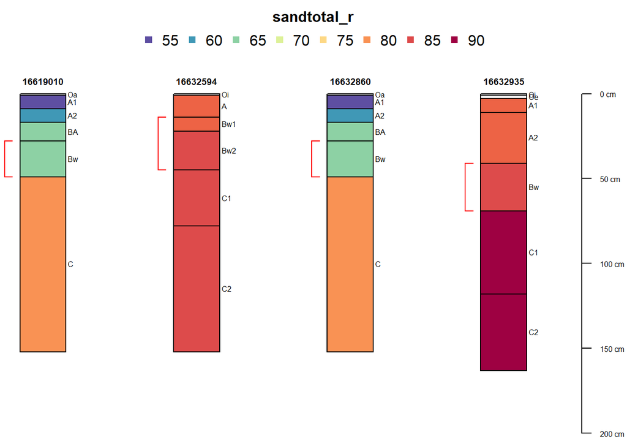

```r
par(mar=c(0,0,3,0))
plot(my.spc.sub, color='sandtotal_r', width=0.15)
addDiagnosticBracket(my.spc.sub, kind='Cambic horizon', col='red', offset=-0.25)
```

Now that we have the data and have done some preliminary inspection, let’s define a regular expression pattern and a function. We will use these to identify horizon texture classes that are “sandy” and components that have sandy cambics.

```r
sandy.texture.pattern <- "-S$|^S$|COS$|L[^V]FS$|[^L]VFS$|LS$|LFS$"
```

Define a custom function `has_sandy_cambic()` to test horizons *within the cambic depth range* for each profile.

```r
# p is a single profile SPC
has_sandy_cambic <- function(p) {
  cambic_top <- p$cambicdept_r
  cambic_bot <- p$cambicdepb_r

  print(paste0(cambic_top,"-",cambic_bot))
  # if top or bottom depth are NULL there is no cambic
  if(!is.null(cambic_top) | !is.null(cambic_bot)) {

    # call glom to get horizons in p between cambic_top and cambic_bot
    cambic_horizons <- glom(p, cambic_top, cambic_bot)

    print(paste0(unique(p$cokey),":", paste0(cambic_horizons$texture, collapse=",")))

    # consider stratified cambics "sandy" -- in that stratification is not allowed per cambic def'n
    if(any(grepl(cambic_horizons$texture,
                 pattern = "SR",
                 ignore.case = TRUE))) {
      return(TRUE)
    }

    # use a regular expression to match the sandy textures
    if(any(grepl(cambic_horizons$texture,
                 pattern = sandy.texture.pattern,
                 ignore.case = TRUE))) {
      return(TRUE)
    }
  }

  return(FALSE)
}
```

Apply the function to each profile.

```r
# apply function has_sandy_cambic() to each profile
my.spc.sub$sandy_cambic <- profileApply(my.spc.sub, has_sandy_cambic)
```

```
## [1] "28-49"
## [1] "16619010:byv-sl,byx-cosl"
## [1] "14-45"
## [1] "16632594:gr-ls,cb-ls,cbv-lfs"
## [1] "28-49"
## [1] "16632860:byv-sl,byx-cosl"
## [1] "41-69"
## [1] "16632935:stv-ls,stv-ls"
```

Inspect results. Print out the offending unique IDs and textural classes (if any).

```r
# do any components have a sandy cambic?
if(any(my.spc.sub$sandy_cambic)) {
  print(paste0("The following components have sandy cambics: ",
        paste0(site(my.spc.sub)[my.spc.sub$sandy_cambic,idname(my.spc)], collapse=",")))
} else {
  print("All components with cambics have appropriate textures.")
}
```

```
## [1] "The following components have sandy cambics: 16632594,16632935"
```

```r
# print a list of the sandy textures in the subset of components with cambics
sandy.idx <- grepl(my.spc.sub$texture,
                   pattern = sandy.texture.pattern,
                   ignore.case = TRUE)
unique(my.spc.sub$texture[sandy.idx])
```

```
## [1] "byx-lcos" "gr-ls"    "cb-ls"    "cbv-lfs"  "stv-lfs"  "st-ls"
## [7] "stv-ls"   "stv-vfs"
```